# Datasets in S and N space

Here is where our communities fall in S and N space:

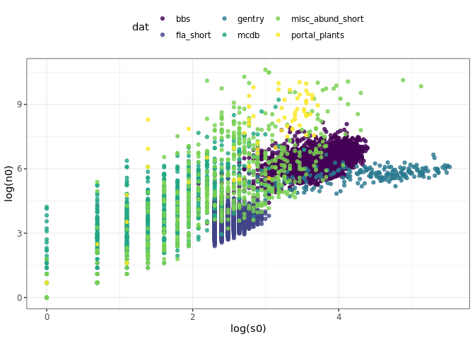

Here is how that translates into the size of the feasible set:

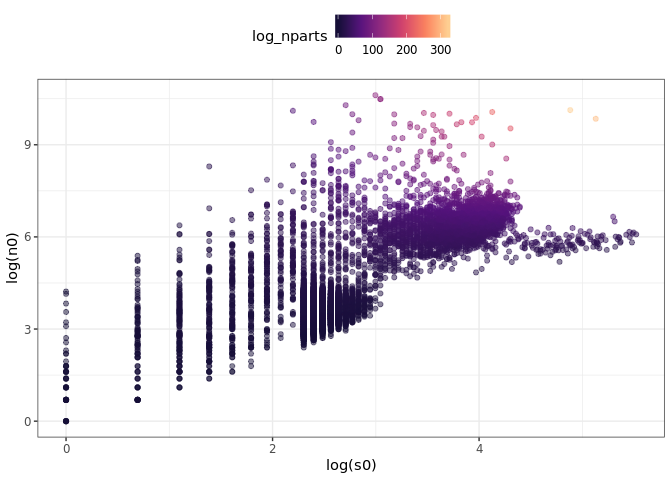

Note that the color scale is log transformed, so the largest communities have e^331.5401042, or 9.683621310^{143}, elements in the feasible set!

Here is how the size of the feasible set maps on to N/S. It increases with n0/s0 and s0.

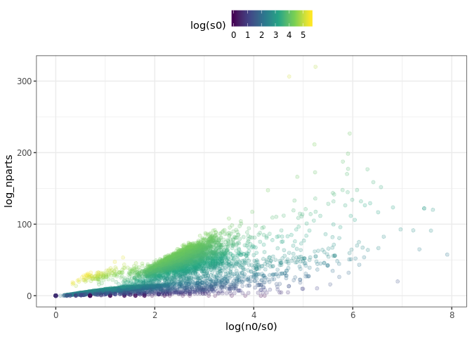

# Number of samples

Here is how many samples we are achieving:

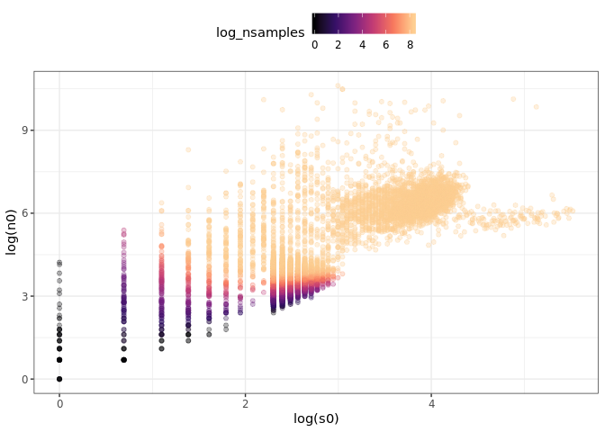

Only in small communities do we get appreciably fewer than 4000 samples.

Here is how the number of samples we're getting compares to the size of the feasible set:

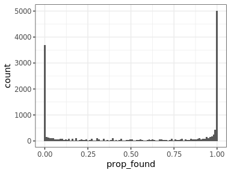

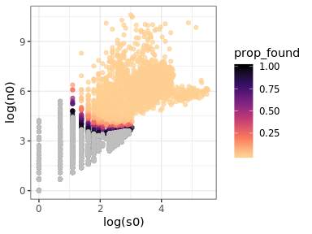

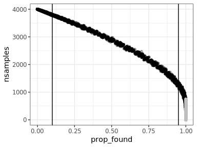

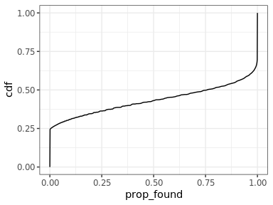

For about 30.3874915% of sites, we found all the elements of the FS. The *vast majority* of this is FIA - here is what happens if we take out FIA:

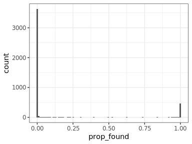

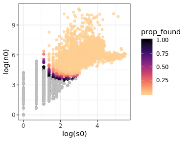

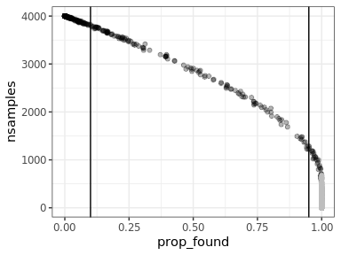

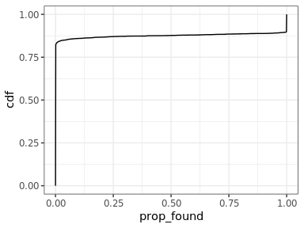

Without FIA, we find all the samples about 10.1262916% of the time.

# Distribution of percentile values

## Skewness

Here is the overall distribution of skewness, and if we split based on whether we found all the samples:

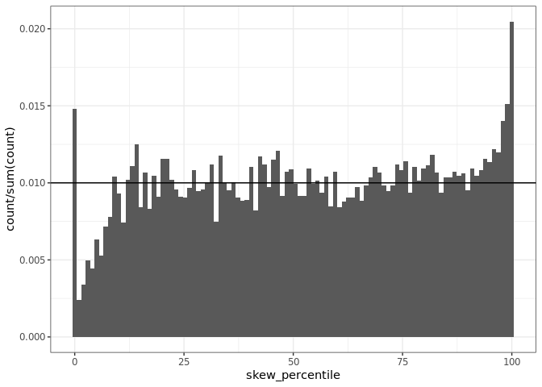

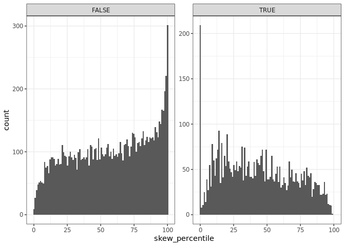

When we found all the samples, the percentiles are more evenly distributed. I do not read much into the spike at 0 for those communities, because skewness is bizarre for very small communities.

Here is how skewness maps with S and N:

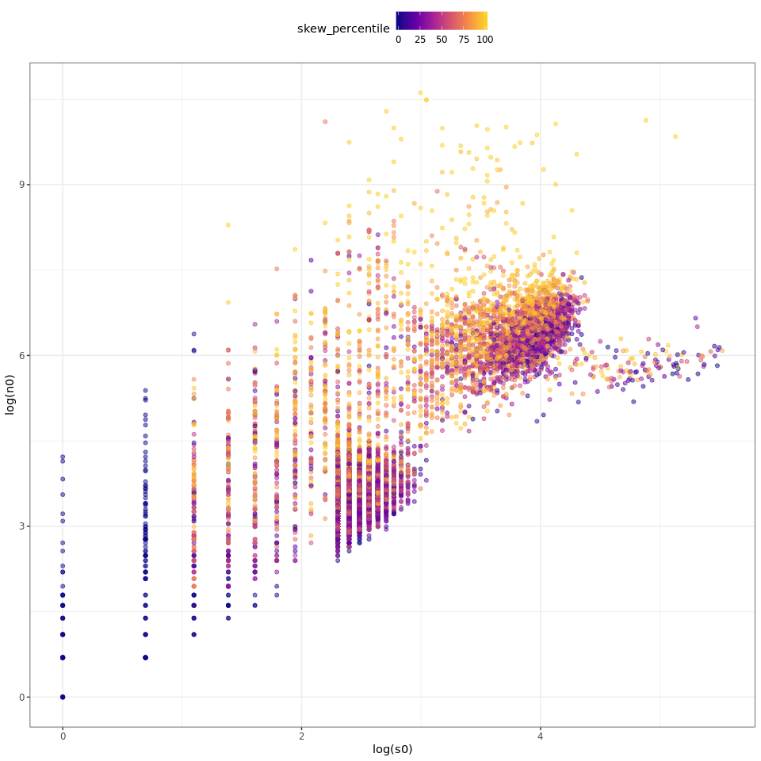

The very low skewness values are down in the very small and very weird communities. There may be variation along S and N elsewhere, but it is hard to parse.

## Simpson

Here is the overall evenness distribution, and split by whether we found 'em all:

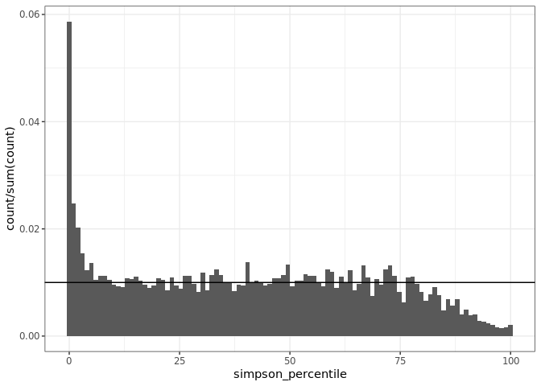

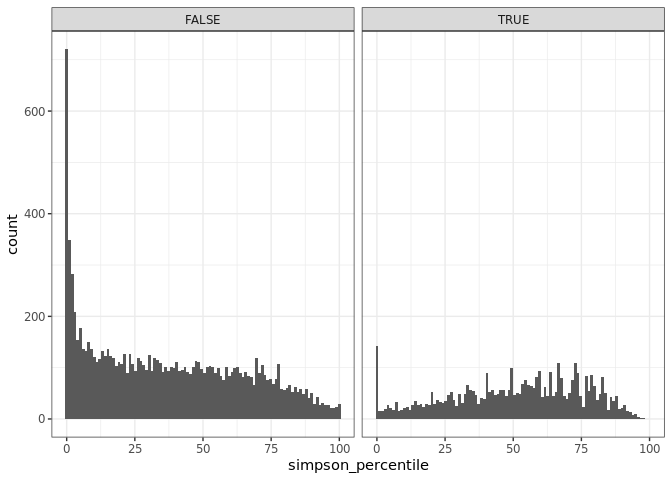

Simpson is less evenly distributed than skewness. Again, where we found them all, we don't see the disproportionately common low percentile values.

Here is how Simpson behaves in S and N space:

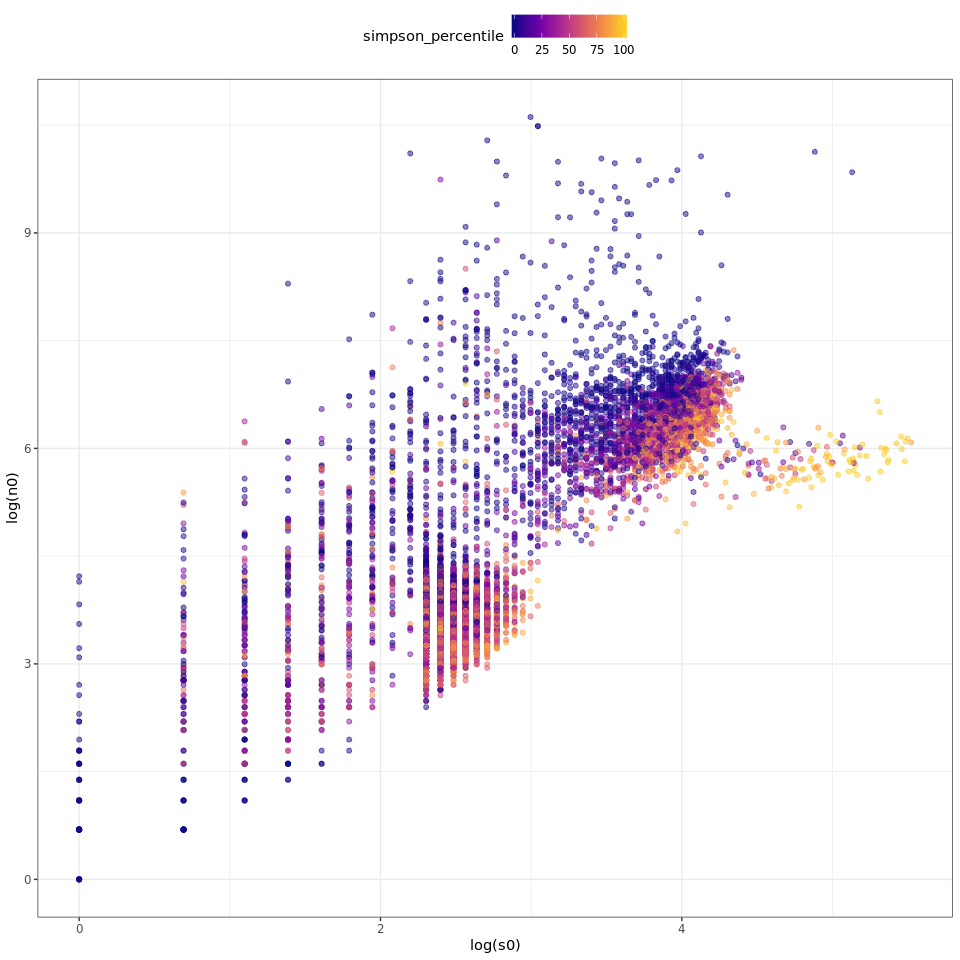

There is unusual behavior where S is large and N/S is relatively small (log N/S <= 1.5), where evenness is unusually *high*.

For both skew and evenness, we do not see non-extreme percentile values in large communities:

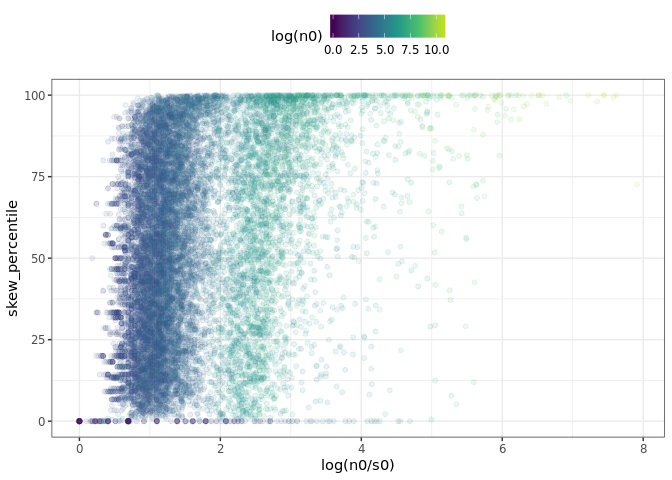

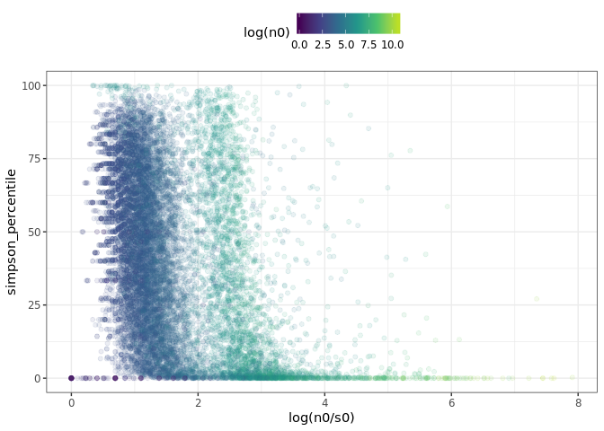

## Singletons

Here is how singletons change percentiles, broken out by whether or not we found all the samples:

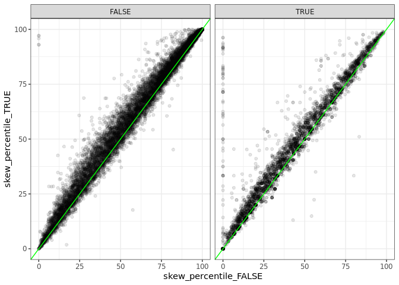

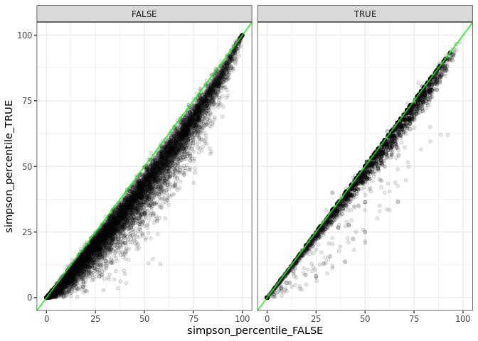

The rarefaction-inflated datasets are strongly // the raw vectors. They have more extreme skewness and evenness values, relative to their feasible sets, than the raw vectors. This is almost always true for evenness, with a little more noise in the skewness signal. But either way, very strong.

# MACD

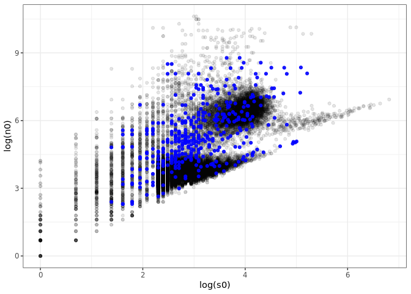

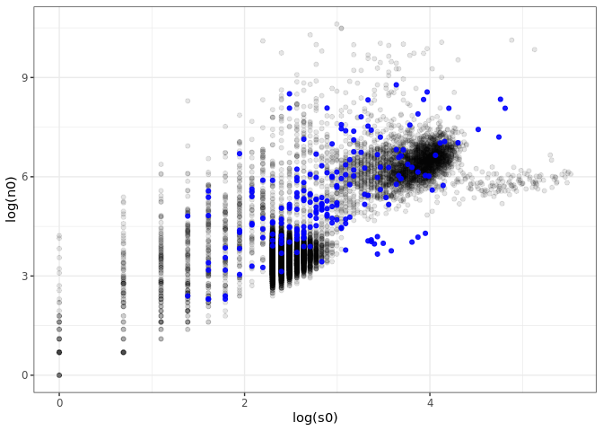

Here are the distributions of skew and evenness, overall.

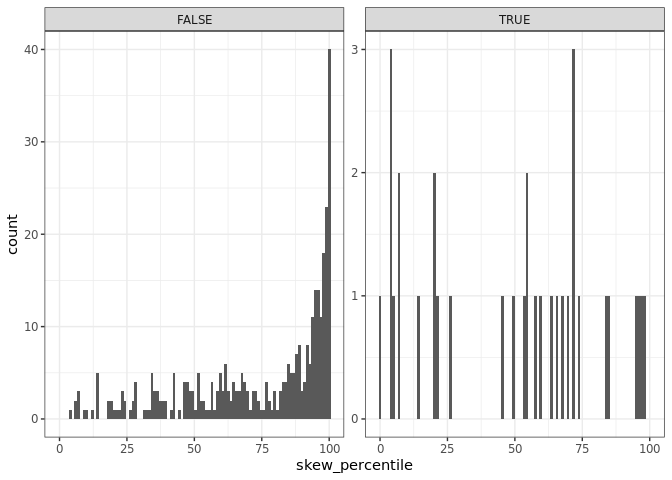

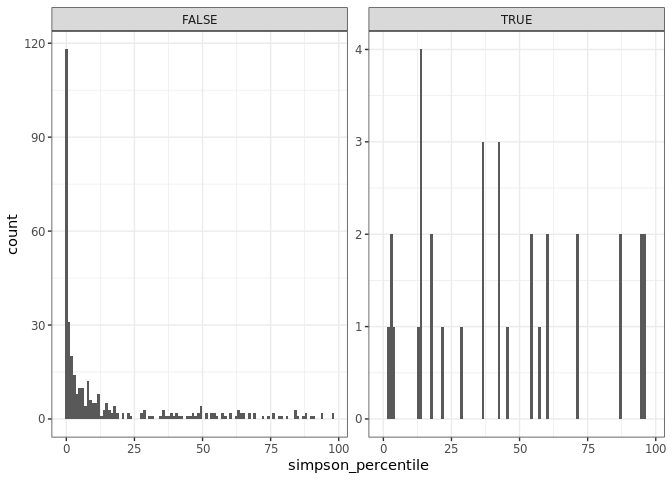

Here is how manipulation affects things:

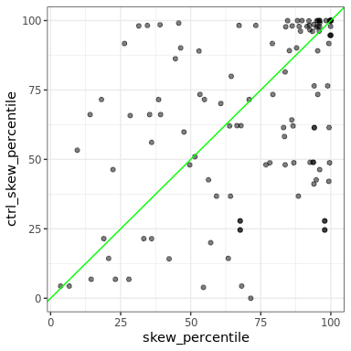

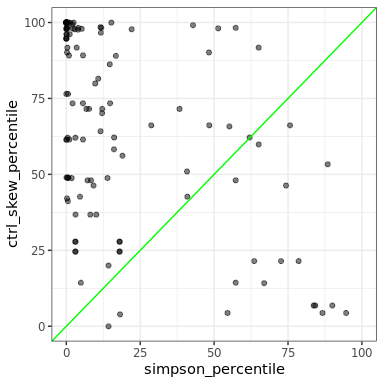

```
## Warning: Removed 2 rows containing non-finite values (stat_bin).
```

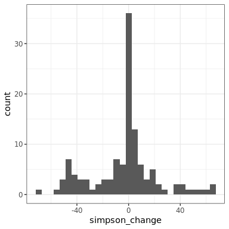

```
## Warning: Removed 2 rows containing non-finite values (stat_bin).
```

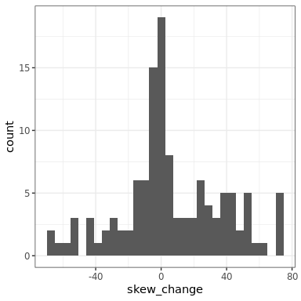

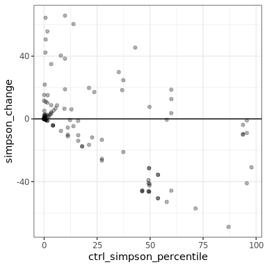

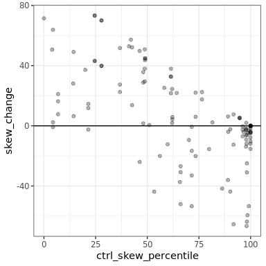

```
##
##  Paired t-test
##
## data:  all_di_macd_manip$skew_percentile and all_di_macd_manip$ctrl_skew_percentile
## t = 2.1644, df = 119, p-value = 0.03243
## alternative hypothesis: true difference in means is not equal to 0
## 95 percent confidence interval:
##   0.5271239 11.8517311
## sample estimates:
## mean of the differences
##                6.189428

##
##  Paired t-test
##
## data:  all_di_macd_manip$simpson_percentile and all_di_macd_manip$ctrl_simpson_percentile
## t = -1.447, df = 119, p-value = 0.1505
## alternative hypothesis: true difference in means is not equal to 0
## 95 percent confidence interval:
##  -8.033839  1.249765
## sample estimates:
## mean of the differences
##               -3.392037

##
##  Wilcoxon signed rank test with continuity correction
##
## data:  all_di_macd_manip$skew_percentile and all_di_macd_manip$ctrl_skew_percentile
## V = 3993, p-value = 0.06652
## alternative hypothesis: true location shift is not equal to 0

##
##  Wilcoxon signed rank test with continuity correction
##
## data:  all_di_macd_manip$simpson_percentile and all_di_macd_manip$ctrl_simpson_percentile
## V = 2680, p-value = 0.2672
## alternative hypothesis: true location shift is not equal to 0
```

Change is going to be bounded at 100 and 0: you can't go up or down from there. (Another argument for increasing the number of samples?)